# Unsupervised Machine Learning with Scikit-learn

# Evaluation Metrics

Correctly measuring the performance of Clustering algorithms is key. This is especially true as it often happens that clusters are manually and qualitatively inspected to determine whether the results are meaningful.

we will go through the main metrics used to evaluate the performance of Clustering algorithms, to rigorously have a set of measures.

- **Silhouette Score**:The Silhouette Score and Silhouette Plot are used to measure the separation distance between clusters. It displays a measure of how close each point in a cluster is to points in the neighbouring clusters. This measure has a range of [-1, 1] and is a great tool to visually inspect the similarities within clusters and differences across clusters. The higher the Silhouette Coefficients (the closer to +1), the further away the cluster’s samples are from the neighbouring clusters samples. A value of 0 indicates that the sample is on or very close to the decision boundary between two neighbouring clusters. Negative values, instead, indicate that those samples might have been assigned to the wrong cluster.
- **Calinski Harabasz Index**: Calinski-Harabasz Index is also known as the Variance Ratio Criterion.The score is defined as the ratio between the within-cluster dispersion and the between-cluster dispersion. The C-H Index is a great way to evaluate the performance of a Clustering algorithm as it does not require information on the ground truth labels.The higher the Index, the better the performance.
- **Davies Bouldin Index**: The Davies-Bouldin index (DBI) is one of the clustering algorithms evaluation measures. It is most commonly used to evaluate the goodness of split by a K-Means clustering algorithm for a given number of clusters. In a few words, the score (DBI) is calculated as the average similarity of each cluster with a cluster most similar to it. The lower the average similarity is, the better the clusters are separated and the better is the result of the clustering performed.

In the next section the process of calculating all the metrics listed above.

```python
from sklearn.metrics import silhouette_samples, silhouette_score,calinski_harabasz_score, davies_bouldin_score,rand_score, adjusted_mutual_info_score, mutual_info_score
```

```python
# creating a function for metrics evaluation,  for reusability purpose
def performance_metric(label):
  """
    Function to for evaluation metrics
  """
  shil_score = silhouette_score(scaled_df, label, metric='euclidean')*100
  db_score = davies_bouldin_score(scaled_df, label)
  cali_score = calinski_harabasz_score(scaled_df, label)
  print('Silhouette_score: %.3f' % shil_score,'\n','Davies Bouldin_score: %.3f' % db_score,'\n','Calinski Harabasz_score: %.3f' % cali_score)
performance_metric(labels)
```

```
Silhouette_score: 20.959
 Davies Bouldin_score: 1.912
 Calinski Harabasz_score: 1706.148
```

The output above displays all the metrics and their various score.

The idea is to try out other algorithms like the DBSCAN and also the Agglomerative clustering algorithm, then perform all this same step, down to the performance evaluation techniques. After which we use the performance evaluation technique to check the best clustering algorithm for thus data set.

# Clustering using Hierarchical Clustering

- Hierarchical Clustering: the process of building a hierarchy or ordering of clusters till only one cluster is left

#### Types of Hierarchical Clustering

- Additive(Agglomerative) hierarchical clustering
  - Agglomerate (merge or join)
  - Assign each point to a cluster
  - Merge/Join closes pairs of clusters into one
  - Repeat until you have a single cluster
  - You keep on adding or joining clusters
- Divisive hierarchical clustering
  - Opposite of Additive
  - Start with a single large cluster
  - Divide/Split the farthest point in the cluster
  - Repeat until each cluster only contains a single data point

#### Terms

- Similarity Distance
- Proximity Matrix: it stores the distances between each point
- Dendogram: used to find the number of clusters
  - A dendrogram is a tree-like diagram that records the sequences of merges or splits.
  - The number of clusters will be the number of vertical lines which are being intersected by the line drawn using the threshold.

#### Agglomerative Hierarchical Clustering

- Merging clusters
- Dendogram to detect n_clusters to use and end at

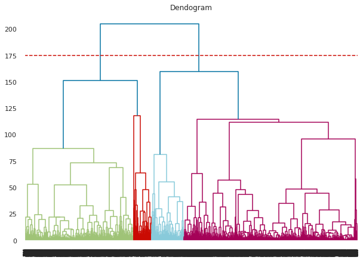

```python
#importing the library for Agglomerative clustering
import scipy.cluster.hierarchy as shc
#Detecting Number of Clusters using Dendogram
plt.figure(figsize= (10,7))
plt.title("Dendogram")
dend = shc.dendrogram(shc.linkage(scaled_df, method='ward'))
plt.axhline(y= 175, color='r', linestyle='--')
```

Using the dendogram diagram shown above, we detect that the number of clusters suitable for the Agglomerative clustering will be 2. This is gotten by the number of point the red line intersects.

Next would be the implementation of the algorithm with clusters attribute equated to 2.

```python
hcluster = AgglomerativeClustering(n_clusters=2, affinity='euclidean', linkage='ward')
cluster_hcl = hcluster.fit_predict(scaled_df)
cluster_hcl
scaled_df['cluster']= cluster_hcl
df_cluster_pca = pd.concat([pca_df, pd.DataFrame({'cluster':cluster_hcl})], axis=1)
```

### PCA Vizualization

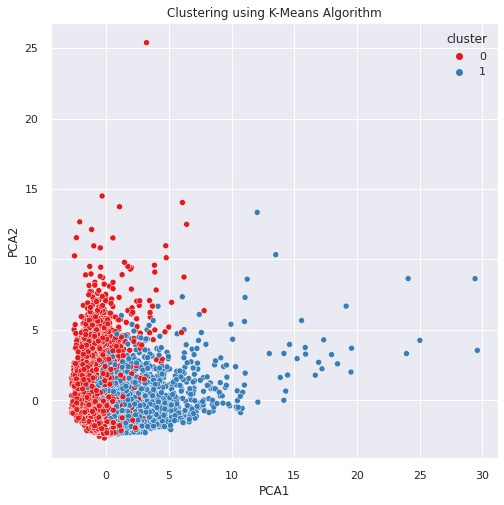

```python
#calling the pca_viz function on the df_cluster_pca dataframe
pca_viz(df_cluster_pca)
```

The plot above shows the clustering derived by the Agglomerative clustering technique.

### Clustering Visualization

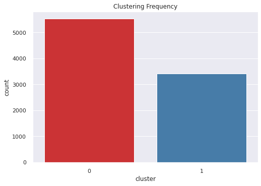

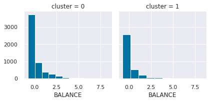

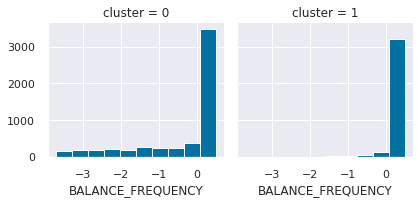

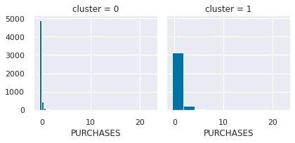

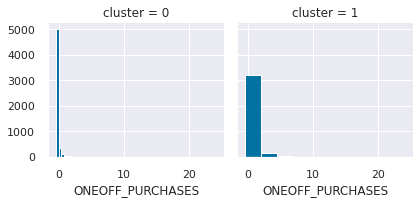

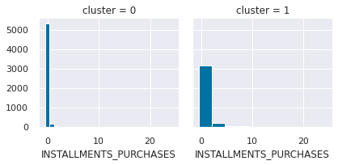

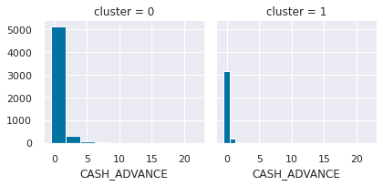

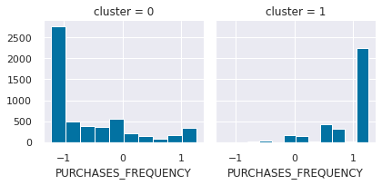

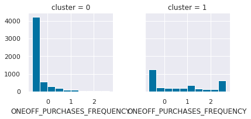

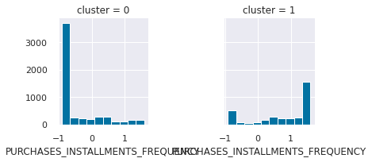

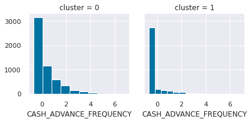

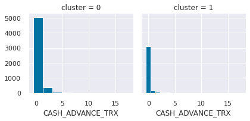

[6 more figures not shown]

```python
cluster_viz(scaled_df)
```

### Performance Evaluation

```python
performance_metric(cluster_hcl)
```

```
Silhouette_score: 19.392
 Davies Bouldin_score: 1.966
 Calinski Harabasz_score: 1568.766
```

# USING DBSCAN

- DBSCAN stands for Density-Based Spatial Clustering of Applications with Noise
- It refers to an unsupervised learning methods that identify distinctive groups/clusters in the data, based on the idea that a cluster in data space is a contiguous region of high point density, separated from other such clusters by contiguous regions of low point density.(kdnuggets)
- DBSCAN is a base algorithm for density-based clustering.
- It can discover clusters of different shapes and sizes from a large amount of data

#### Usefulness

- Unsupervised ML
- Outlier Detection
- Noise detection

#### Terms

The DBSCAN algorithm uses two parameters:

- eps (ε): A distance measure that will be used to locate the points in the neighborhood of any point.
- minPts: The minimum number of points (a threshold) clustered together for a region to be considered dense.
  - minPt >= Dimensions of dataset + 1
- Core point — This is a point that has at least m points within distance n from itself.
- Border — This is a point that has at least one Core point at a distance n.
- Noise — This is a point that is neither a Core nor a Border. And it has less than m points within distance n from itself.

These parameters can be understood if we explore two concepts called Density Reachability and Density Connectivity.

Reachability in terms of density establishes a point to be reachable from another if it lies within a particular distance (eps) from it.

Connectivity, on the other hand, involves a transitivity based chaining-approach to determine whether points are located in a particular cluster. For example, p and q points could be connected if p->r->s->t->q, where a->b means b is in the neighborhood of a.

```python
#importing the required libraries
from sklearn.cluster import DBSCAN
from sklearn.neighbors import NearestNeighbors
```

implementing DBSCAN with Elbow Method to get the best number of clusters just as was done for the kMeans algorithm

```
min samples: 38
shape of distance matrix: (8950, 38)
```

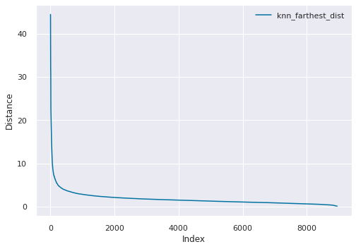

```
elbow at k = 2 clusters
```

```python
# finding the best value of eps to use
min_samples = scaled_df.shape[1]*2
k = min_samples if min_samples > 2 else 2
nbrs = NearestNeighbors(n_neighbors=k).fit(scaled_df)
distance, indices = nbrs.kneighbors(scaled_df)
print("min samples: "+ str(min_samples))
print("shape of distance matrix: "+ str(distance.shape)+"\n")
# the last cell represents the distance of the Kth farthest point
scaled_df['knn_farthest_dist'] = distance[:,-1]
scaled_df.sort_values('knn_farthest_dist', ascending=False).reset_index()[['knn_farthest_dist']].plot()
plt.xlabel('Index')
plt.ylabel('Distance')
plt.grid(True)
plt.show()
#!pip install kneed
from kneed import KneeLocator
cost_knee_c3 = KneeLocator(
            x=scaled_df['knn_farthest_dist'],
            y=range(0,8950),
            S=0.1, curve="convex",direction="decreasing",online=True)

K_cost_c3 = cost_knee_c3.elbow
print("elbow at k =", f'{K_cost_c3:.0f} clusters')
```

From the above output, the best value is 2

**NOTE: That in the case of DBSCAN we are using the elbow method to find the best eps value**

Another approach to finding the best eps value is by using the idea or trying to find the best clusterings with the lesser amount of noise (for DBSCAN clusters classified as -1 are called noise).

To do this;

- we would create our own function to to check the number of clusters made by the algorithm when a certain value for eps is imputed
- Next we would use the elbow estimate "2" as our boundary, and iterate our function through 1 and 2 with a step or 0.1. Just to actively see the performance of the model when a certain value in the range is considered by the model.
- After which we finally pick the eps value which has the lowest amount of noise and more significant clustering.

**NOTE: If we have an output which seems to have 2 clusters, for examples output with classification of 0 and -1, this should be taken as one cluster. For the DBSCAN approach, -1 is not a cluster but a noise**.

```python
# creating a Function to check the number of clusters i = eps value
def dbscan_cluster_checker(i):
  """
   Function to check the number of clusters
   i = eps value
  """
  km= DBSCAN(eps=i, min_samples=min_samples)
  scaled_df['cluster'] = km.fit_predict(scaled_df[column_names])
  print("At eps={}\n".format(i),scaled_df.cluster.value_counts())
  print("--"*100,'\n')
```

```python
#checking for lesser noise value by iterating from 1 to 2 with an interval of 0.1
start = 1.0
stop = 2.0
step = 0.1
float_range_array = np.arange(start, stop, step)
float_range_list = list(float_range_array)
for i in float_range_list:
  print(dbscan_cluster_checker(i))
```

```
At eps=1.0
 -1    4793
 0    4110
 1      47
Name: cluster, dtype: int64
--------------------------------------------------------------------------------------------------------------------------------------------------------------------------------------------------------

None
At eps=1.1
  0    4709
-1    4155
 2      54
 1      32
Name: cluster, dtype: int64
--------------------------------------------------------------------------------------------------------------------------------------------------------------------------------------------------------

None
At eps=1.2000000000000002
  0    5222
-1    3670
 1      58
Name: cluster, dtype: int64
--------------------------------------------------------------------------------------------------------------------------------------------------------------------------------------------------------

None
At eps=1.3000000000000003
  0    5711
-1    3239
Name: cluster, dtype: int64
--------------------------------------------------------------------------------------------------------------------------------------------------------------------------------------------------------

None
At eps=1.4000000000000004
  0    6088
-1    2770
 2      64
 1      28
Name: cluster, dtype: int64
--------------------------------------------------------------------------------------------------------------------------------------------------------------------------------------------------------

```

[output cut: 22 more lines]

```
None
At eps=1.8000000000000007
  0    7543
-1    1407
Name: cluster, dtype: int64
--------------------------------------------------------------------------------------------------------------------------------------------------------------------------------------------------------

None
At eps=1.9000000000000008
  0    7735
-1    1215
Name: cluster, dtype: int64
--------------------------------------------------------------------------------------------------------------------------------------------------------------------------------------------------------

None
```

Recall that it's the eps value that produces a lesser number of noise i.e, -1, and significant clusters, which in our case would be **1.5**.

### PCA Vizualization

```
At eps=1.5
  0    6530
-1    2311
 1     109
Name: cluster, dtype: int64
--------------------------------------------------------------------------------------------------------------------------------------------------------------------------------------------------------
```

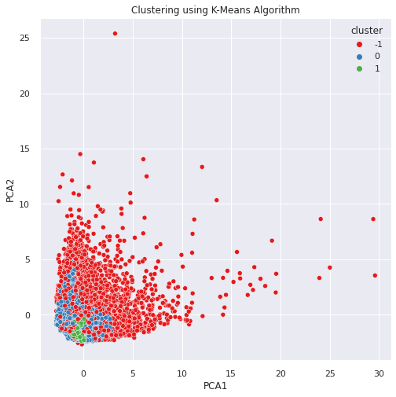

```python
# implementing dbscan with eps = 1.5
dbscan_cluster_checker(1.5)


df_cluster_pca = pd.concat([pca_df, scaled_df['cluster']], axis=1)

df_cluster_pca.cluster.value_counts()

pca_viz(df_cluster_pca)

#plt.figure(figsize=(10,7))
#plt.scatter(df_cluster_pca['PCA1'],df_cluster_pca['PCA2'],c=df_cluster_pca['cluster'])
```

The above plot displaces the clustering performed by DBSCAN.

### Clustering Visualization

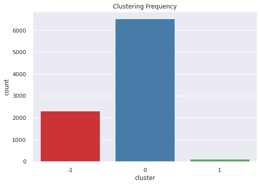

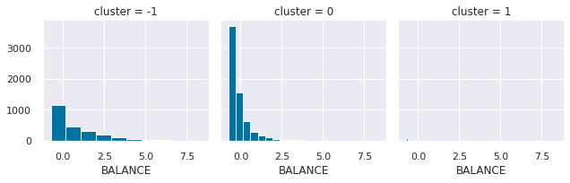

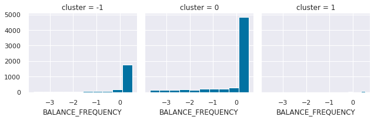

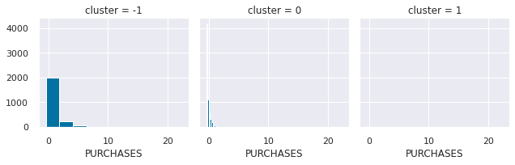

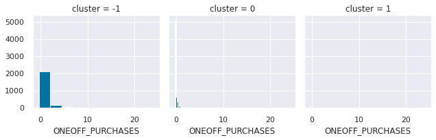

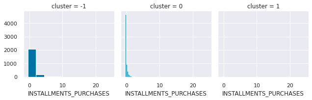

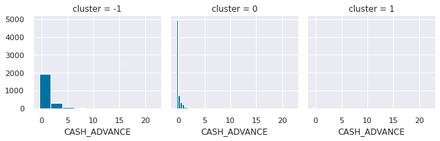

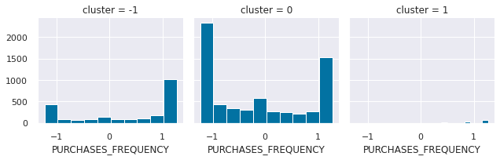

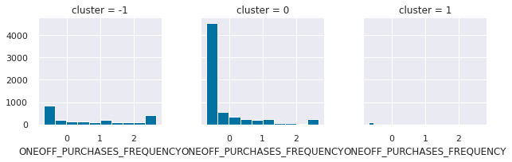

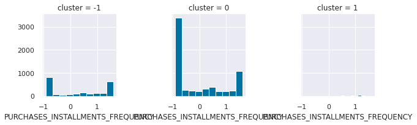

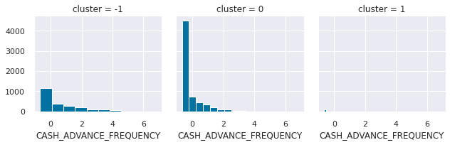

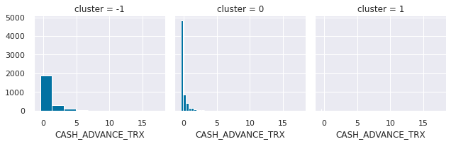

[6 more figures not shown]

```python
cluster_viz(scaled_df)
```

### Performance Metric

```python
performance_metric(scaled_df.cluster)
```

```
Silhouette_score: 18.340
 Davies Bouldin_score: 1.809
 Calinski Harabasz_score: 808.150
```